# Modelo Votante

## todos influenciam todos

## probabilidades das opiniões iniciais: (50%, 50%)

## alocação aleatória

```python
model = models.ModeloVotante(n_actors = 10,
                              influence_mode = 'all',
                              possible_opinions = [-1,1],
                              opinions_probabilities = [5/10,5/10],
                              randomize_start_opinions= True,
                              #initial_opinions_list = [-1,-1,-1,-1,-1,1,1,1,1,1]
                              )

model.make_graph()
```

[figure not shown]

```
Numero de runs: 1000

          count       mean  median        std  opinions_prob  random  \
opiniao
-1         504  56.099206      43  45.719193            0.5    True
 1         496  62.945565      45  54.171101            0.5    True

        influence_mode
opiniao
-1                 all
 1                 all
```

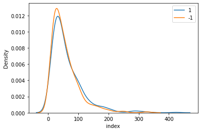

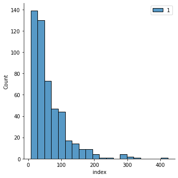

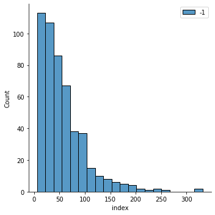

```python
data_9 = make_final_opinions_analysis(model)
```

## todos influenciam todos

## probabilidades das opiniões iniciais: (50%, 50%)

## alocação separada

```python
model = models.ModeloVotante(n_actors = 10,
                              influence_mode = 'all',
                              possible_opinions = [-1,1],
                              opinions_probabilities = [5/10,5/10],
                              randomize_start_opinions= False,
                              )

model.make_graph()
```

[figure not shown]

```
Numero de runs: 1000

          count       mean  median        std  opinions_prob  random  \
opiniao
-1         509  56.960707      43  46.795526            0.5   False
 1         491  57.723014      44  45.033464            0.5   False

        influence_mode
opiniao
-1                 all
 1                 all
```

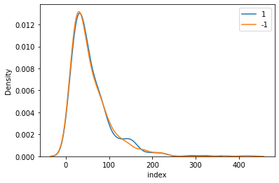

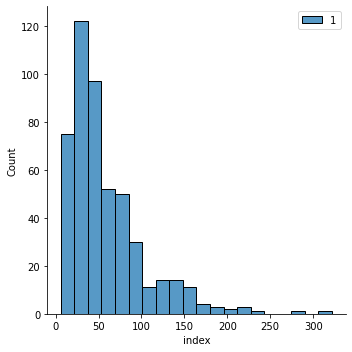

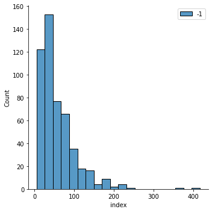

```python
data_10 = make_final_opinions_analysis(model)
```

## todos influenciam todos

## probabilidades das opiniões iniciais: (70%, 30%)

## alocação aleatória

```python
model = models.ModeloVotante(n_actors = 10,
                              influence_mode = 'all',
                              possible_opinions = [-1,1],
                              opinions_probabilities = [7/10,3/10],
                              randomize_start_opinions= True,
                              )

model.make_graph()
```

[figure not shown]

```
Numero de runs: 1000

          count       mean  median        std  opinions_prob  random  \
opiniao
-1         702  43.548433      29  41.695518            0.7    True
 1         298  71.684564      56  50.425942            0.3    True

        influence_mode
opiniao
-1                 all
 1                 all
```

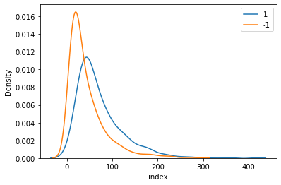

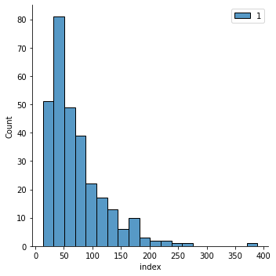

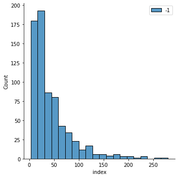

```python
data_11 = make_final_opinions_analysis(model)
```

## todos influenciam todos

## probabilidades das opiniões iniciais: (70%, 30%)

## alocação separada

```python
model = models.ModeloVotante(n_actors = 10,
                              influence_mode = 'all',
                              possible_opinions = [-1,1],
                              opinions_probabilities = [7/10,3/10],
                              randomize_start_opinions= False,
                              )

model.make_graph()
```

[figure not shown]

```
Numero de runs: 1000

          count       mean  median        std  opinions_prob  random  \
opiniao
-1         720  43.912500    29.0  42.787593            0.7   False
 1         280  71.264286    58.5  47.133473            0.3   False

        influence_mode
opiniao
-1                 all
 1                 all
```

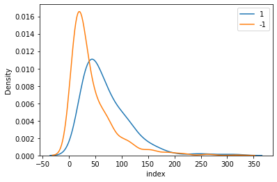

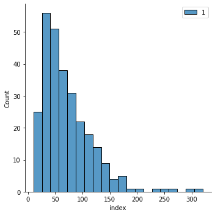

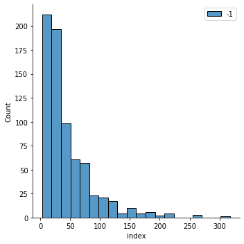

```python
data_12 = make_final_opinions_analysis(model)
```

```python
results = [data_1[1],
            data_2[1],
            data_3[1],
            data_4[1],
            data_5[1],
            data_6[1],
            data_7[1],
            data_8[1],
            data_9[1],
            data_10[1],
            data_11[1],
            data_12[1]
          ]


df = pd.concat(results)

df.to_csv('../data/results/aula1.csv')
```

```python
df = pd.read_csv('../data/results/aula1.csv').iloc[:,1:]
```

```python
df[df.opinions_prob == 0.5].sort_values('mean')
```

|  | opiniao | count | mean | median | std | opinions_prob | random | influence_mode |
| --- | --- | --- | --- | --- | --- | --- | --- | --- |
| 0 | -1 | 504 | 56.099206 | 43.0 | 45.719193 | 0.5 | True | all |
| 0 | -1 | 509 | 56.960707 | 43.0 | 46.795526 | 0.5 | False | all |
| 1 | 1 | 491 | 57.723014 | 44.0 | 45.033464 | 0.5 | False | all |
| 1 | 1 | 496 | 62.945565 | 45.0 | 54.171101 | 0.5 | True | all |
| 1 | 1 | 517 | 106.367505 | 80.0 | 94.038506 | 0.5 | True | circular_neighbors |
| 0 | -1 | 483 | 110.942029 | 84.0 | 92.960086 | 0.5 | True | circular_neighbors |
| 0 | -1 | 495 | 116.006061 | 88.0 | 94.079205 | 0.5 | False | circular_neighbors |
| 1 | 1 | 505 | 122.562376 | 98.0 | 94.206969 | 0.5 | False | circular_neighbors |
| 1 | 1 | 491 | 144.181263 | 101.0 | 135.067291 | 0.5 | True | linear_neighbors |
| 0 | -1 | 509 | 164.836935 | 105.0 | 173.298440 | 0.5 | True | linear_neighbors |
| 1 | 1 | 497 | 198.372233 | 142.0 | 168.581619 | 0.5 | False | linear_neighbors |
| 0 | -1 | 503 | 206.248509 | 163.0 | 161.835647 | 0.5 | False | linear_neighbors |

```python
df[df.opinions_prob.isin([0.3,0.7])].sort_values(['mean'])
```

|  | opiniao | count | mean | median | std | opinions_prob | random | influence_mode |
| --- | --- | --- | --- | --- | --- | --- | --- | --- |
| 0 | -1 | 702 | 43.548433 | 29.0 | 41.695518 | 0.7 | True | all |
| 0 | -1 | 720 | 43.912500 | 29.0 | 42.787593 | 0.7 | False | all |
| 1 | 1 | 280 | 71.264286 | 58.5 | 47.133473 | 0.3 | False | all |
| 1 | 1 | 298 | 71.684564 | 56.0 | 50.425942 | 0.3 | True | all |
| 0 | -1 | 680 | 75.977941 | 41.5 | 94.338786 | 0.7 | True | circular_neighbors |
| 0 | -1 | 701 | 91.649073 | 52.0 | 101.116296 | 0.7 | False | circular_neighbors |
| 0 | -1 | 711 | 99.457103 | 44.0 | 134.828981 | 0.7 | True | linear_neighbors |
| 1 | 1 | 320 | 137.471875 | 110.5 | 100.269195 | 0.3 | True | circular_neighbors |
| 0 | -1 | 738 | 138.127371 | 80.0 | 153.929957 | 0.7 | False | linear_neighbors |
| 1 | 1 | 299 | 148.903010 | 118.0 | 108.384324 | 0.3 | False | circular_neighbors |
| 1 | 1 | 289 | 194.543253 | 149.0 | 155.471703 | 0.3 | True | linear_neighbors |
| 1 | 1 | 262 | 268.610687 | 204.5 | 199.559191 | 0.3 | False | linear_neighbors |

```python
df[df.opinions_prob.isin([0.5])].groupby('opiniao').mean()
```

| opiniao | count | mean | median | std | opinions_prob | random |
| --- | --- | --- | --- | --- | --- | --- |
| -1 | 500.5 | 118.515575 | 87.666667 | 102.448016 | 0.5 | 0.5 |
| 1 | 499.5 | 115.358659 | 85.000000 | 98.516492 | 0.5 | 0.5 |

```python
df[df.opinions_prob.isin([0.3,0.7])].groupby('opiniao').mean()
```

| opiniao | count | mean | median | std | opinions_prob | random |
| --- | --- | --- | --- | --- | --- | --- |
| -1 | 708.666667 | 82.112070 | 45.916667 | 94.782855 | 0.7 | 0.5 |
| 1 | 291.333333 | 148.746279 | 116.083333 | 110.207305 | 0.3 | 0.5 |

É possível observar que:

- existe uma relação entre a distribuição de opiniões iniciais e a convergência para uma determinada opinião. Pelos exemplos acima, mantem-se praticamente a mesma proporção entre opiniões iniciais e opinião de consenso após convergência. Quando atores com opiniões -1 possuem a mesma quantidade de atores com opinião 1, 50% das corridas, aproximadamente, tem consenso final em cada opinião. Quando a probabilidade de atribuição de uma opinão muda (caso estudado - 0.7 e 0.3) o numero de corridas que tem consenso na primeira opinião é proximo a 70%.
- Quando existe um desbalanço inicial de opiniões, a média de tempo para convergir para a opinião com maior numero de atores é menor do que o tempo para convergir para a opinião dividida entre menos atores
- Mantendo a proporção de opiniões fixas, o modelo que todos os atores influenciam todos é o que converge mais rápido, seguido pela configuração que todos estão em um circulo e por útlimo a configuração onde estão em fila.
- corridas com opiniões distribuídas randomicamente entre os atores tendem a convergir mais rápido do que quando há segregação de opiniões, para configurações que só existe interações entre vizinhos.

```python
df
```

|  | opiniao | count | mean | median | std | opinions_prob | random | influence_mode |
| --- | --- | --- | --- | --- | --- | --- | --- | --- |
| 0 | -1 | 509 | 164.836935 | 105.0 | 173.298440 | 0.5 | True | linear_neighbors |
| 1 | 1 | 491 | 144.181263 | 101.0 | 135.067291 | 0.5 | True | linear_neighbors |
| 2 | -1 | 503 | 206.248509 | 163.0 | 161.835647 | 0.5 | False | linear_neighbors |
| 3 | 1 | 497 | 198.372233 | 142.0 | 168.581619 | 0.5 | False | linear_neighbors |
| 4 | -1 | 711 | 99.457103 | 44.0 | 134.828981 | 0.7 | True | linear_neighbors |
| 5 | 1 | 289 | 194.543253 | 149.0 | 155.471703 | 0.3 | True | linear_neighbors |
| 6 | -1 | 738 | 138.127371 | 80.0 | 153.929957 | 0.7 | False | linear_neighbors |
| 7 | 1 | 262 | 268.610687 | 204.5 | 199.559191 | 0.3 | False | linear_neighbors |
| 8 | -1 | 483 | 110.942029 | 84.0 | 92.960086 | 0.5 | True | circular_neighbors |
| 9 | 1 | 517 | 106.367505 | 80.0 | 94.038506 | 0.5 | True | circular_neighbors |
| 10 | -1 | 495 | 116.006061 | 88.0 | 94.079205 | 0.5 | False | circular_neighbors |
| 11 | 1 | 505 | 122.562376 | 98.0 | 94.206969 | 0.5 | False | circular_neighbors |
| 12 | -1 | 680 | 75.977941 | 41.5 | 94.338786 | 0.7 | True | circular_neighbors |
| 13 | 1 | 320 | 137.471875 | 110.5 | 100.269195 | 0.3 | True | circular_neighbors |
| 14 | -1 | 701 | 91.649073 | 52.0 | 101.116296 | 0.7 | False | circular_neighbors |
| 15 | 1 | 299 | 148.903010 | 118.0 | 108.384324 | 0.3 | False | circular_neighbors |
| 16 | -1 | 504 | 56.099206 | 43.0 | 45.719193 | 0.5 | True | all |
| 17 | 1 | 496 | 62.945565 | 45.0 | 54.171101 | 0.5 | True | all |
| 18 | -1 | 509 | 56.960707 | 43.0 | 46.795526 | 0.5 | False | all |
| 19 | 1 | 491 | 57.723014 | 44.0 | 45.033464 | 0.5 | False | all |
| 20 | -1 | 702 | 43.548433 | 29.0 | 41.695518 | 0.7 | True | all |
| 21 | 1 | 298 | 71.684564 | 56.0 | 50.425942 | 0.3 | True | all |
| 22 | -1 | 720 | 43.912500 | 29.0 | 42.787593 | 0.7 | False | all |
| 23 | 1 | 280 | 71.264286 | 58.5 | 47.133473 | 0.3 | False | all |

```python
df.groupby(['influence_mode', 'random', 'opinions_prob', 'opiniao']).mean()
```

| influence_mode | random | opinions_prob | opiniao | count | mean | median | std |
| --- | --- | --- | --- | --- | --- | --- | --- |
| all | False | 0.3 | 1 | 280 | 71.264286 | 58.5 | 47.133473 |
|  |  | 0.5 | -1 | 509 | 56.960707 | 43.0 | 46.795526 |
|  |  |  | 1 | 491 | 57.723014 | 44.0 | 45.033464 |
|  |  | 0.7 | -1 | 720 | 43.912500 | 29.0 | 42.787593 |
|  | True | 0.3 | 1 | 298 | 71.684564 | 56.0 | 50.425942 |
|  |  | 0.5 | -1 | 504 | 56.099206 | 43.0 | 45.719193 |
|  |  |  | 1 | 496 | 62.945565 | 45.0 | 54.171101 |
|  |  | 0.7 | -1 | 702 | 43.548433 | 29.0 | 41.695518 |
| circular_neighbors | False | 0.3 | 1 | 299 | 148.903010 | 118.0 | 108.384324 |
|  |  | 0.5 | -1 | 495 | 116.006061 | 88.0 | 94.079205 |
|  |  |  | 1 | 505 | 122.562376 | 98.0 | 94.206969 |
|  |  | 0.7 | -1 | 701 | 91.649073 | 52.0 | 101.116296 |
|  | True | 0.3 | 1 | 320 | 137.471875 | 110.5 | 100.269195 |
|  |  | 0.5 | -1 | 483 | 110.942029 | 84.0 | 92.960086 |
|  |  |  | 1 | 517 | 106.367505 | 80.0 | 94.038506 |
|  |  | 0.7 | -1 | 680 | 75.977941 | 41.5 | 94.338786 |
| linear_neighbors | False | 0.3 | 1 | 262 | 268.610687 | 204.5 | 199.559191 |
|  |  | 0.5 | -1 | 503 | 206.248509 | 163.0 | 161.835647 |
|  |  |  | 1 | 497 | 198.372233 | 142.0 | 168.581619 |
|  |  | 0.7 | -1 | 738 | 138.127371 | 80.0 | 153.929957 |
|  | True | 0.3 | 1 | 289 | 194.543253 | 149.0 | 155.471703 |
|  |  | 0.5 | -1 | 509 | 164.836935 | 105.0 | 173.298440 |
|  |  |  | 1 | 491 | 144.181263 | 101.0 | 135.067291 |
|  |  | 0.7 | -1 | 711 | 99.457103 | 44.0 | 134.828981 |